# NYCFlights: Arrival Delay Logictic Model

Saqib Ali

May 1st, 2017

## Logsitic and Inverse Logistic Transformation

- Write an R function for the logistic function. The function should accept a `numeric` vector with values `[-Inf,Inf]` and produce a numeric vector in the the range `[0,1]`.
- Plot the logistic function from `[-10,10]`
- Write a R function for the inverse logistic function. The function should accept a `numeric` vector with values `[0,1]` and prodcuce a numeric vector in the range `[-Inf,Inf]`
- Plot the Inverse Logistic function from `[0,1]`

**Hint:** For plotting curves see `?graphics::curve` or `?ggplot2::stat_function`

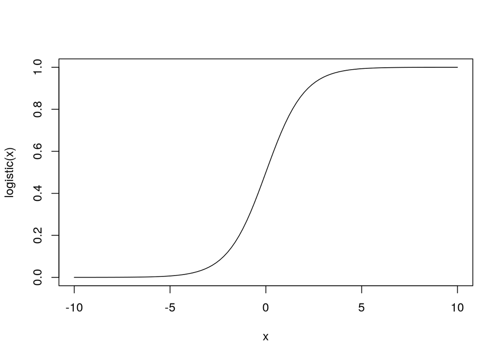

```r
logistic <- function(x) {
  1/(1+exp(-x))
}

inv_logistic <- function(x) {
  -log((1-x)/x)
}

x <- -10:10
curve(logistic, -10, 10)
```

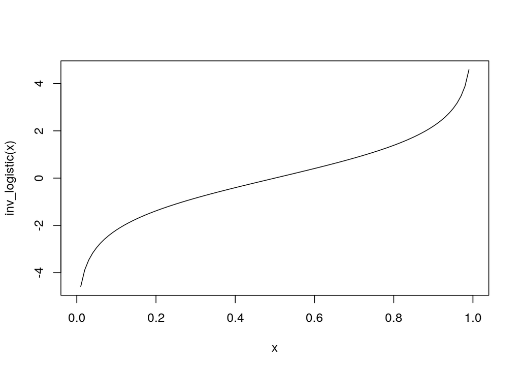

```r
curve(inv_logistic, 0, 1)
```

# NYCFlights Model

Using the rectangular data that you created from the earlier assignment and following theexample from the text and class, create a model for arr_delay >= 22 minutes. Describe/Explain each of the steps and show all work.

KNIT YOUR DOCUMENT AS *HTML* AND SUBMIT IT AND THE `Rmd` file to your repository.

## Join the datasets and analyze the structure

```r
YX <- flightsDT
YX %<>% merge( planesDT, all.x = TRUE, by='tailnum', suffixes=c('','.pl') )
YX %<>% merge( weatherDT, all.x = TRUE, by=c('origin','year','month','day','hour'), suffixes=c('','.we') )
YX %<>% merge( airportsDT, all.x = TRUE, by.x='origin', by.y='faa', suffixes=c('','.orig') )
YX %<>% merge( airportsDT, all.x = TRUE, by.x='dest', by.y='faa', suffixes=c('','.dest') )
data.joined <- YX
```

## Add a categorical variable for arr_delay >= 22 minutes. It is called arrival_delayed

```r
data.joined$arrival_delayed <- ifelse(data.joined$arr_delay >= 22, 1,0)
```

## Remove entries with NA values for Independant variables that we want to use in the model

```r
data.joined <- data.joined  %>%
  filter(!is.na(dep_delay))   %>%
  filter(!is.na(dest))   %>%
  filter(!is.na(origin))   %>%
  filter(!is.na(year))   %>%
  filter(!is.na(month))   %>%
  filter(!is.na(day))   %>%
  filter(!is.na(hour))   %>%
  filter(!is.na(tailnum))   %>%
  filter(!is.na(sched_dep_time))   %>%
  filter(!is.na(sched_arr_time))   %>%
  filter(!is.na(flight))   %>%
  filter(!is.na(distance))   %>%
  filter(!is.na(year.pl))   %>%
  filter(!is.na(minute))   %>%
  filter(!is.na(year.pl))   %>%
  filter(!is.na(type))   %>%
  filter(!is.na(manufacturer))   %>%
  filter(!is.na(model))   %>%
  filter(!is.na(engines))   %>%
  filter(!is.na(seats))   %>%
  filter(!is.na(engine))   %>%
  filter(!is.na(temp))   %>%
  filter(!is.na(dewp))   %>%
  filter(!is.na(humid))   %>%
  filter(!is.na(wind_dir))   %>%
  filter(!is.na(wind_speed))   %>%
  filter(!is.na(wind_gust))   %>%
  filter(!is.na(precip))   %>%
  filter(!is.na(pressure))   %>%
  filter(!is.na(visib))   %>%
  filter(!is.na(name))   %>%
  filter(!is.na(lat))   %>%
  filter(!is.na(lon))   %>%
  filter(!is.na(tz))   %>%
  filter(!is.na(name.dest))   %>%
  filter(!is.na(lat.dest))   %>%
  filter(!is.na(lon.dest))   %>%
  filter(!is.na(alt.dest))   %>%
  filter(!is.na(tz.dest))
```

## Create Training and Test Samples

```r
data.joined.training <- sample_frac(data.joined, .75)
data.joined.testing <- sample_frac(data.joined, .5)
```

## Generate a Logistic Model

```r
logit.fit <- glm(arrival_delayed ~  dep_delay + dest + origin + year + month + day + hour + sched_dep_time + sched_arr_time + carrier + distance + year.pl + type  + engines + seats + engine + temp + dewp + humid + wind_dir + wind_speed + wind_gust +precip + pressure + visib + lat + lon + alt + tz  + lat.dest + lon.dest + alt.dest + tz.dest, data = data.joined.training, family = binomial)
#summary(logit.fit)
```

## Predict

```r
prob = plogis(predict(logit.fit, data.joined.testing))
```

# Question:

Is this a good model? (Write your answer here.)

To answer this let’s first calculate the misclassifications, Specificity and Sensitivity of the model.

## Model Evaluation

### Decide on optimal prediction probability cutoff for the model

Using the InformationValue::optimalCutoff we determine the optimal cut-off

```r
optimalCutoff(data.joined.testing$arrival_delayed, prob)[1]
```

```
## [1] 0.5
```

```r
optCutOff <- optimalCutoff(data.joined.testing$arrival_delayed, prob)[1]
```

### Mis-classification rate

```r
misClassError(data.joined.testing$arrival_delayed, prob, threshold = optCutOff)
```

```
## [1] 0.0726
```

### Sensitivity

```r
sensitivity(data.joined.testing$arrival_delayed, prob, threshold = optCutOff)
```

```
## [1] 0.695771
```

### Specificity

```r
specificity(data.joined.testing$arrival_delayed, prob, threshold = optCutOff)
```

```
## [1] 0.9795539
```

### Confusion Matrix

```r
confusionMatrix(data.joined.testing$arrival_delayed, prob, threshold = optCutOff)
```

```
##       0     1
## 0 93279  6568
## 1  1947 15021
```

## Conclusion

Based on the Confusion Matrix results, high Specificity and high Sensitivity and very low mis-classification errors this is a fairly good model, with high accuracy, sensitivity and specivity.

# PART B:

Your model should be good at explaining tardiness. Now, assume that your job is to predict arrival delays a month in advance. You can no longer use all the features in your model. Retrain your model using only features that will be *known* only a month in advance of the departure time. Show all steps as above.

```r
logit.fit <- glm(arrival_delayed ~  dest + origin + sched_dep_time + sched_arr_time + carrier + distance + lat + lon + alt + tz  + lat.dest + lon.dest + alt.dest + tz.dest, data = data.joined.training, family = binomial(link="logit"))
```

## Model Evaluation

Let’s see how good this model is using a Confusion Matrix.

### Decide on optimal prediction probability cutoff for the model

Using the InformationValue::optimalCutoff we determine the optimal cut-off

```r
prob = plogis(predict(logit.fit, data.joined.testing))
optimalCutoff(data.joined.testing$arrival_delayed, prob)[1]
```

```
## [1] 0.4900354
```

```r
optCutOff <- optimalCutoff(data.joined.testing$arrival_delayed, prob)[1]
```

### Mis-classification rate

```r
misClassError(data.joined.testing$arrival_delayed, prob, threshold = optCutOff)
```

```
## [1] 0.184
```

### Sensitivity

Note that the **Sensitivity** is very low

```r
sensitivity(data.joined.testing$arrival_delayed, prob, threshold = optCutOff)
```

```
## [1] 0.001713836
```

### Specificity

```r
specificity(data.joined.testing$arrival_delayed, prob, threshold = optCutOff)
```

```
## [1] 0.999811
```

### Confusion Matrix

```r
confusionMatrix(data.joined.testing$arrival_delayed, prob, threshold = optCutOff)
```

```
##       0     1
## 0 95208 21552
## 1    18    37
```

## Conclusion

Based on the Confusion Matrix results, and a very low Sensitivity, we can conclude that this is **NOT** a Model Fit.

```r
#prob = predict(logit.fit, data.joined.sample, type="response")
#prob = plogis(predict(logit.fit, data.joined.testing))
#prob<-ifelse(prob> 0.5,1,0)
#data.joined.testing$prob = prob
```